# Tugas Praktikum 2 No. 2

Fitria Angelita Delvi

2026-08-30

# Input Data

```r
data2 <- data.frame(
  year = 1975:2014,
  sales = c(
    11.7, 12.0, 12.3, 12.8, 13.1, 13.6, 13.9, 14.4, 14.7, 15.3,
    15.5, 15.8, 16.1, 16.6, 16.9, 16.7, 16.9, 17.4, 17.6, 17.9,
    18.0, 17.9, 18.0, 18.2, 18.2, 18.3, 18.6, 19.2, 19.3, 19.5,
    19.2, 19.3, 19.5, 20.0, 20.0, 19.9, 19.8, 19.9, 20.2, 21.0
  ),
  advertising = c(
    9.4, 9.6, 10.0, 10.4, 10.8, 10.9, 11.7, 12.2, 12.5, 12.9,
    13.0, 13.2, 13.8, 14.2, 14.6, 14.4, 15.0, 15.4, 15.7, 15.9,
    15.9, 16.0, 16.3, 16.2, 16.8, 17.3, 17.6, 18.1, 18.3, 18.5,
    18.7, 18.9, 19.2, 20.0, 20.0, 20.3, 20.4, 21.0, 21.5, 22.1
  )
)
```

# Eksplorasi Data

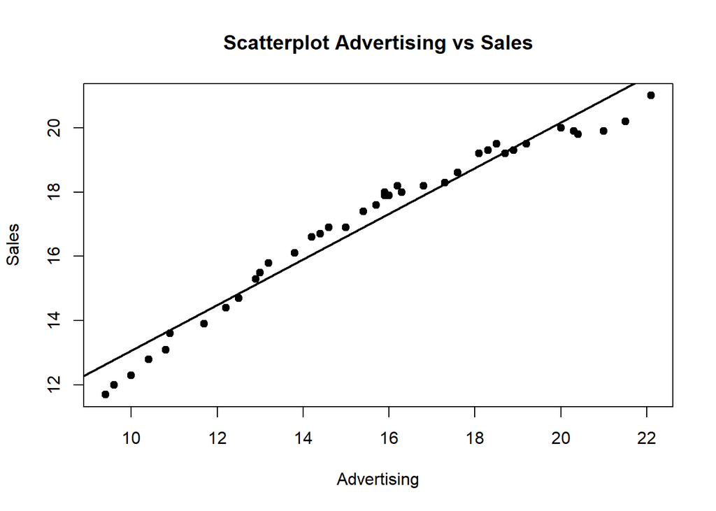

```r
plot(
  data2$advertising,
  data2$sales,
  pch = 19,
  xlab = "Advertising",
  ylab = "Sales",
  main = "Scatterplot Advertising vs Sales"
)

abline(
  lm(sales ~ advertising, data = data2),
  lwd = 2
)
```

Berdasarkan scatterplot, terlihat adanya hubungan positif dan cukup linear antara Advertising dan Sales. Semakin besar Advertising, maka Sales cenderung meningkat. Titik-titik pengamatan juga relatif dekat dengan garis regresi, sehingga hubungan kedua peubah terlihat cukup kuat.

# Model OLS

```r
model_ols2 <- lm(
  sales ~ advertising,
  data = data2
)

summary(model_ols2)
```

```
##
## Call:
## lm(formula = sales ~ advertising, data = data2)
##
## Residuals:
##      Min       1Q   Median       3Q      Max
## -1.03758 -0.40343  0.08933  0.45674  0.74036
##
## Coefficients:
##             Estimate Std. Error t value Pr(>|t|)
## (Intercept)  5.96513    0.38092   15.66   <2e-16 ***
## advertising  0.71035    0.02365   30.04   <2e-16 ***
## ---
## Signif. codes:  0 '***' 0.001 '**' 0.01 '*' 0.05 '.' 0.1 ' ' 1
##
## Residual standard error: 0.527 on 38 degrees of freedom
## Multiple R-squared:  0.9596, Adjusted R-squared:  0.9585
## F-statistic: 902.3 on 1 and 38 DF,  p-value: < 2.2e-16
```

Berdasarkan hasil regresi OLS, diperoleh persamaan Sales = 5.9651 + 0.7103 Advertising. Koefisien Advertising bernilai positif, sehingga peningkatan Advertising cenderung diikuti dengan peningkatan Sales. Koefisien Advertising juga signifikan pada taraf 5%. Nilai R-squared sebesar 0.9596 menunjukkan bahwa sekitar 95.96% variasi Sales dapat dijelaskan oleh Advertising.

# Plot Sisaan

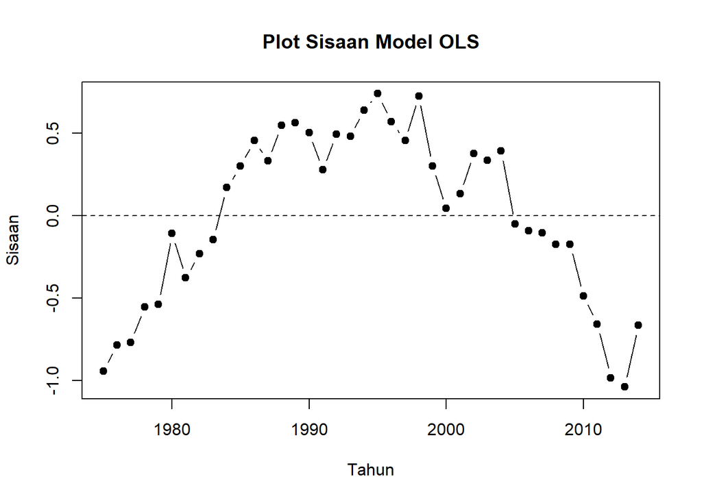

```r
resid_ols2 <- residuals(model_ols2)

plot(
  data2$year,
  resid_ols2,
  type = "b",
  pch = 19,
  xlab = "Tahun",
  ylab = "Sisaan",
  main = "Plot Sisaan Model OLS"
)

abline(h = 0, lty = 2)
```

Berdasarkan plot sisaan model OLS, sisaan tidak menyebar secara acak di sekitar garis nol dan terlihat adanya pola tertentu sepanjang waktu. Sisaan awalnya cenderung negatif, kemudian meningkat menjadi positif, dan kembali menurun menjadi negatif pada periode akhir. Pola tersebut mengindikasikan adanya autokorelasi pada sisaan, sehingga perlu dilakukan pengujian lebih lanjut menggunakan uji Durbin-Watson.

# Durbin-Watson

```r
library(lmtest)
dwtest(model_ols2)
```

```
##
##  Durbin-Watson test
##
## data:  model_ols2
## DW = 0.16204, p-value < 2.2e-16
## alternative hypothesis: true autocorrelation is greater than 0
```

Berdasarkan plot sisaan terlihat adanya pola pada sisaan. Hasil uji Durbin-Watson juga menghasilkan nilai DW sebesar 0.162 yang mengindikasikan adanya autokorelasi positif pada sisaan. Oleh karena itu, perlu dilakukan penanganan autokorelasi.

# Cochrane-Orcutt

```r
library(orcutt)

model_co2 <- cochrane.orcutt(model_ols2)

summary(model_co2)
```

```
## Call:
## lm(formula = sales ~ advertising, data = data2)
##
##              Estimate Std. Error t value  Pr(>|t|)
## (Intercept) 10.252375   1.459736   7.023 2.638e-08 ***
## advertising  0.488489   0.075426   6.476 1.426e-07 ***
## ---
## Signif. codes:  0 '***' 0.001 '**' 0.01 '*' 0.05 '.' 0.1 ' ' 1
##
## Residual standard error: 0.1868 on 37 degrees of freedom
## Multiple R-squared:  0.5313 ,  Adjusted R-squared:  0.5186
## F-statistic: 41.9 on 1 and 37 DF,  p-value: < 1.426e-07
##
## Durbin-Watson statistic
## (original):    0.16204 , p-value: 8.935e-20
## (transformed): 1.93925 , p-value: 3.78e-01
```

Berdasarkan hasil metode Cochrane-Orcutt, diperoleh model Sales = 10.2524 + 0.4885 Advertising. Koefisien Advertising bernilai positif dan signifikan dengan p-value sebesar 1.426e-07, sehingga peningkatan Advertising cenderung diikuti dengan peningkatan Sales. Nilai R-squared sebesar 0.5313 menunjukkan bahwa 53.13% variasi Sales pada model transformasi dapat dijelaskan oleh Advertising. Pada model awal diperoleh nilai Durbin-Watson sebesar 0.16204 dengan p-value 8.935e-20 yang menunjukkan adanya autokorelasi positif. Setelah dilakukan transformasi Cochrane-Orcutt, nilai Durbin-Watson meningkat menjadi 1.93925 dengan p-value 0.378. Karena p-value > 0.05 dan nilai DW mendekati 2, tidak terdapat bukti adanya autokorelasi positif pada sisaan setelah dilakukan penanganan.

# Plot Residual Setelah Cochrane-Orcutt

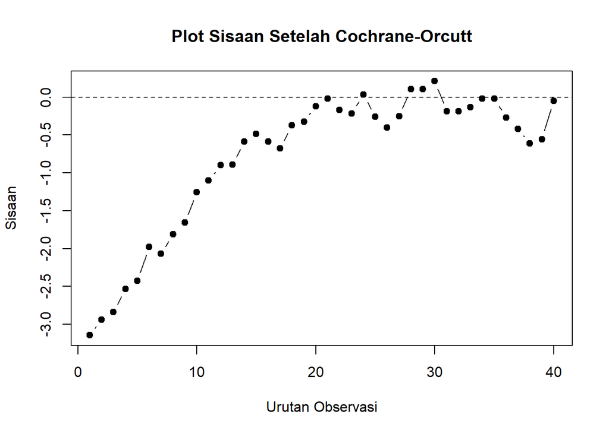

```r
resid_co2 <- residuals(model_co2)

plot(
  resid_co2,
  type = "b",
  pch = 19,
  xlab = "Urutan Observasi",
  ylab = "Sisaan",
  main = "Plot Sisaan Setelah Cochrane-Orcutt"
)

abline(h = 0, lty = 2)
```

# Hildreth-Lu

```r
rho_grid <- seq(0, 0.99, by = 0.01)

hasil_hl2 <- data.frame(
  rho = rho_grid,
  SSE = sapply(rho_grid, function(rho) {

    y_star <- data2$sales[-1] -
      rho * data2$sales[-nrow(data2)]

    x_star <- data2$advertising[-1] -
      rho * data2$advertising[-nrow(data2)]

    model <- lm(y_star ~ x_star)

    sum(resid(model)^2)
  })
)

hasil_hl2[which.min(hasil_hl2$SSE), ]
```

```
##    rho      SSE
## 91 0.9 1.291395
```

Berdasarkan pencarian awal nilai rho dengan metode Hildreth-Lu, diperoleh nilai rho = 0.90 yang menghasilkan nilai SSE terkecil, yaitu sebesar 1.291395. Oleh karena itu, nilai rho = 0.90 digunakan sebagai acuan untuk melakukan pencarian rho yang lebih rinci di sekitar nilai tersebut.

# Perhalus Rho

```r
rho_fine2 <- seq(0.89, 0.91, by = 0.001)

hasil_fine2 <- data.frame(
  rho = rho_fine2,
  SSE = sapply(rho_fine2, function(rho) {

    y_star <- data2$sales[-1] -
      rho * data2$sales[-nrow(data2)]

    x_star <- data2$advertising[-1] -
      rho * data2$advertising[-nrow(data2)]

    model <- lm(y_star ~ x_star)

    sum(resid(model)^2)
  })
)

hasil_fine2[which.min(hasil_fine2$SSE), ]
```

```
##      rho      SSE
## 14 0.903 1.291226
```

Setelah dilakukan pencarian rho yang lebih rinci di sekitar nilai awal 0.90, diperoleh nilai rho = 0.903 yang menghasilkan SSE terkecil, yaitu sebesar 1.291226. Oleh karena itu, rho = 0.903 dipilih sebagai nilai rho optimal dalam metode Hildreth-Lu.

```r
rho_hl2 <- 0.903
```